# Impacto da COVID-19 nos Estudantes Universitários no Brasil

## 4. PROCESSAMENTO E TRATAMENTO DE DADOS

Antes de iniciar a dissertar sobre o processamento e tratamento de dados é importante conceituar o que é dados. De acordo com a Fia (2019, não paginado) “dados representam uma série de fatos, conceitos ou estatísticas que podem ser analisados para produzir informações”.  
Os dados originais coletados da pesquisa foram extraídos da ferramenta forms por meio de um arquivo externo ao ambiente de análise dos dados em uma planilha de cálculos. Como em todo processo de AED, houve a necessidade de normalização e padronização dos conteúdos para uso nas análises realizadas neste artigo.  
De acordo com Han, Kamber e Pei (2011) o processo de AED contempla a limpeza, preparação e tratamento dos dados, conhecido como a fase de pré-processamento. Esta fase é essencial para análise dos dados e conforme estudo, 80% da análise dos dados é consumida na limpeza e preparação dos dados (WICKHAM, 2014). O autor ainda ressalta que a preparação dos dados não é realizados apenas uma vez e sim em vários momentos e no percurso da análise dos dados, ao passo que novas problemáticas e lacunas surgem e novos dados são coletados ou acrescentados na pesquisa. Contato, apesar da importância da preparação dos dados e o tempo que consome faltam estudos na área sobre como limpar bem os dados e o processo sendo denominado também pelos autores como “higienização” (da SILVA, 2021). Como os dados utilizados nesta análise vieram de questionários aplicados em diferentes etapas da pandemia (entre 2020 e 2023) alguns processos de limpeza e preparação foram empregados com o objetivo de normalizar as informações destes diferentes períodos.  
Para a realização das etapas de preparação, transformação, organização e estruturação foram utilizados recursos da **Linguagem R**, um software livre de programação voltada ao tratamento, análise e visualização de dados. A linguagem é largamente utilizada por acadêmicos, estatísticos e analistas de dados para realizar projetos de AED.  
A linguagem foi desenvolvida originalmente no departamento de Estatística da Universidade de Auckland, Nova Zelândia e sua manutenção é realizada por uma comunidade de colaboradores voluntários que contribuem para melhoria e otimização da linguagem e com a expansão das suas funcionalidades básicas por meio de bibliotecas, ou **packages** residentes no repositório *CRAN-R* (The Comprehensive R Archive Network) (LINGUAGEM R, 2022)[^1]. Com o objetivo de facilitar e agilizar o processo de desenvolvimento dos cálculos estatísticos e geração de gráficos na linguagem R, utilizou-se também o **Ambiente de Desenvolvimento Integrado** (do inglês Integrated Development Environment – IDE) *RStudio*, um programa de computador de fonte aberta com características e ferramentas de apoio ao desenvolvimento acelerado de software (LINGUAGEM R, 2022).  
Portanto, como tarefa inicial para a organização e estruturação dos dados, no Quadro 1 é possível visualizar o dicionário de dados com os nomes e as definições das variáveis utilizadas nesta AED.

Quadro 1: Dicionário de dados.

| Nome da variável | Tipo de variável | Conteúdo | Descrição |
| --- | --- | --- | --- |
| data/ano | data | dd/mm/aaaa | Dia, mês e ano em que o questionário foi aplicado |
| idade | númerica | Idade da(o) respondente | Faixa etária dos respondentes |
| genero | texto | Feminino, Masculino, Outros ou NR | Gênero da(o) inquirida(o) |
| situacao_conjugal | texto | Solteiro, Casado, União Estável/Vivendo junto, Divorciado/Separado, Viúvo, NR | Situação conjugal |
| situacao_empregaticia | texto | Dependente, Bolsista, Estagiário, Empregado, Desempregado | Situação empregatícia e/ou financeira atual |
| estado_reside | texto | SP, RJ, MG… | 27 estados da federação e DF |
| ies | texto | Instituição de Ensino Superior | Nome da IES da(o) estudante |
| nome_curso | texto | Graduação ou pós-graduação. | Nome do curso da(o) estudante |
| nível_ensino | texto | Graduação ou pós-graduação. | Nível do curso da(o) estudante |
| data_inicio_ curso | data | dd/mm/aaaa | Dia, mês e ano em que a(o) estudante inicou o curso na IES |
| tipo_ies | texto | Privada, Pública, Outras | Tipo da IES |
| local_estudante | texto | Local, Outra cidade, NR | Local de origem do estudante |
| migrou_virtual | texto | Sim, Não, Não sei | Instituição migrou para as aulas virtuais |
| ies_fechou_dorm | texto | Sim, Não, Não sei, Não se aplica | Instituição fechou dormitórios |
| situação_durante_pandemia | texto | texto livre (até 250 palavras) | Conjunto e diversidade da situação da pandemiana sua instituição |
| data_fechamento | data | dd/mm/aaaa | Dia, mês e ano em que a IES fechou |
| residencia_atual | texto | No campus universitário instituciona, Fora do campus, mas na mesma cidade da instituição de ensino, Em outra cidade da instituição de ensino mas dentro do mesmo estado, Em uma cidade em outro Estado, … | Onde o aluno está vivendo ou residindo atualmente |
| moradia_atual_permanente | texto | Sim, Não | Moradia atual do aluno é uma residência permanente e estável |
| morando_com | texto | Colega de quarto/República, Família, Sozinho(a) | Aluno morando ou residindo com/em |
| convive_risco_relevante | texto | Sim, Não | Aluno morando ou convivendo atualmente com alguém na faixa etária dos 60-70 anos, e/ou que tenha algum fator de risco relevante |
| quarentena_imposta | texto | Sim, Não, Não sei | Aluno convive ou que está ou esteve em quarentena imposta pela COVID-19 |
| vivenciou | texto | Ajuda ou assistência de pessoas desconhecidas, Discriminação por pessoas desconhecidas, Dificuldades devido a alterações em suas condições de vida, incluindo o fechamento de alojamentos, perda de empr… | Aluno vivenciou durante a pandemia |
| acesso_servicos_saude | texto | N/A ou Não sabe, Muito pior do que antes, Pior do que antes, O mesmo de antes, Melhor do que antes, Muito melhor do que antes | Como o aluno classifica o acesso aos serviços de saúde, comparado a antes e durante a pandemia |
| acesso_internet | texto | N/A ou Não sabe, Muito pior do que antes, Pior do que antes, O mesmo de antes, Melhor do que antes, Muito melhor do que antes | Como o aluno classifica o acesso aos serviços de internet, comparado a antes e durante a pandemia |
| capacidade_prosseguir_estudos | texto | N/A ou Não sabe, Muito pior do que antes, Pior do que antes, O mesmo de antes, Melhor do que antes, Muito melhor do que antes | Como o aluno classifica sua capacidade em prosseguir seus estudos, incluindo sua graduação e/ou conclusão de curso |
| capacidade_socializacao | texto | N/A ou Não sabe, Muito pior do que antes, Pior do que antes, O mesmo de antes, Melhor do que antes, Muito melhor do que antes | Como o aluno classifica a sua capacidade de socialização |
| bem_estar_psicologico | texto | N/A ou Não sabe, Muito pior do que antes, Pior do que antes, O mesmo de antes, Melhor do que antes, Muito melhor do que antes | Como o aluno classifica seu bem-estar psicológico em geral, incluindo sentimentos de ansiedade e/ou depressão |
| qualidade_de_vida | texto | texto livre (até 250 palavras) | Variedade e diversidade de experiências com relação qualidade de vida do aluno |
| aulas_durante_pandemia | texto | Pioraram, Foram mais ou menos o mesmo, Melhoraram, N/A ou Não sabe | Opinião sobre a forma como as aulas foram ministradas durante a pandemia |
| acesso_professores | texto | Piorou, Foi mais ou menos o mesmo, Melhorou, N/A ou Não sabe | Opinião sobre formas de acesso aos seus professores durante a pandemia |
| acesso_infra_ies | texto | Pioraram, Foram mais ou menos o mesmo, Melhorou, N/A ou Não sabe | Opinião sobre formas de acesso aos recursos de infraestrutura oferecidos pela IES |
| espaco_físico | texto | Piorou, Era mais ou menos o mesmo, Melhorou, N/A ou Não sabe | Opinião sobre formas de acesso aos recursos de infraestrutura oferecidos pela IES |
| disposicao_atividades | texto | Diminuiu, Ficou mais ou menos a mesma, Aumentou, N/A ou Não sabe | Opinião sobre disposição para participar das aulas/atividades, estudar e aprender |
| desempenho_escolar | texto | Diminuiu, Ficou mais ou menos a mesma, Aumentou, N/A ou Não sabe | Opinião sobre desempenho escolar durante a pandemia |
| ies_reinicio | texto | Sim (retornou todas as atividades presenciais), Não, ainda não retornou nenhuma atividade presencial, Em parte (apenas algumas atividades presenciais retornaram), N/A ou Não sabe | A IES reiniciou atividades presenciais no campus e/ou faculdade |
| data_reinicio | data | dd/mm/aaaa | Dia, mês e ano em que a IES retornou atividades |
| vacinado | texto | Sim, com uma dose, Sim vacinado com duas doses ou com vacina de dose única, Sim, vacinado com duas doses ou com vacina de dose única e dose(s) de reforço, Não fui vacinado ainda com nenhuma dose, N/A … | Aluno vacinado contra a COVID-19 |
| dificuldades_academicas | texto | texto livre (até 250 palavras) | Variedade e diversidade de experiências com relação às dificuldades acadêmicas do aluno na pandemia |
| despesas | texto | Diminuiram, Ficou mais ou menos os mesmos, Aumentaram, N/A ou Não quero responder | Gastos/despesas do aluno durante a pandemia |
| renda_Financeira | texto | Diminuiu, Está mais ou menos a mesma, Aumentou, N/A ou Não sabe | Alteração na renda financeira do aluno durante a pandemia |
| ajuda_Financeira | texto | Sim, Não, NA / Não sei | Recebeu ajuda financeira da IES ou outra organização durante a pandemia |
| nivel_endividamento | texto | Diminuiram, Estão mais ou menos as mesmas, Aumentaram, N/A ou Não sabe | Dívidas (nível de endividamento) do aluno durante a pandemia |
| despesas_cresceram | texto | Relacionadas com saúde, Viagens/deslocamentos, Transporte urbano, Aluguel, Internet, Alimentação, Outras (não relacionadas) | Dívidas (nível de endividamento) do aluno durante a pandemia |
| dificuldades_financeiras | texto | texto livre (até 250 palavras) | Variedade e diversidade de experiências com relação às dificuldades financeiras do aluno na pandemia |
| decisao_fechar | texto | Muito rapidamente, De forma oportuna e prudente, Muito lentamente, N/A ou Não sabe | Opinião sobre decisão da IES em fechar o campus e utilizar ferramentas online para as aulas |
| ies_positivo | texto | texto livre (até 250 palavras) | Opinião sobre o que a IES fez de positivo em resposta à pandemia |
| ies_melhorar | texto | texto livre (até 250 palavras) | Opinião sobre o que a IES poderia ter melhorado em resposta à pandemia |
| ies_ajudar | texto | texto livre (até 250 palavras) | Opinião sobre comoa IES poderia ter ajudado mais em resposta à pandemia |
| nivel_ansiedade | texto | N/A ou Não sabe, Muito pior do que antes, Pior do que antes, O mesmo de antes, Melhor do que antes, Muito melhor do que antes | Nível de ansiedade do aluno na pandemia |
| ansiedade_planejamento | texto | N/A ou Não sabe, Muito pior do que antes, Pior do que antes, O mesmo de antes, Melhor do que antes, Muito melhor do que antes | Ansiedade do aluno para planejamento pessoal |
| ansiedade_longo_prazo | texto | N/A ou Não sabe, Muito pior do que antes, Pior do que antes, O mesmo de antes, Melhor do que antes, Muito melhor do que antes | Ansiedade do aluno para planejamento de longo prazo |
| detalhes_finais | texto | texto livre (até 250 palavras) | Relatar de forma detalhada e livre como vivenciou a COVID-19 |

Fonte: Elaborado por João Pedro Albino (2023).

No Tópico 5 serão mostrados o conjunto de gráficos utilizados na pesquisa em tela.

## 5. GERAÇÃO DE GRÁFICOS PARA VISUALIZAÇÃO E GERAÇÃO DE CONCLUSÕES

Todos os dados apresentados, coletados e tratados pela pesquisa foram inseridos na forma de código no programa RStudio. Um projeto foi gerado dentro do programa a fim de processar os dados já tratados e transformá-los em gráficos visualizáveis para que as conclusões pudessem ser retiradas do estudo.  
O DataViz (ou data visualization) é a representação gráfica de um conjunto de dados (como barras, mapas ou esquemas), para que eles possam ser interpretados mais rapidamente, a partir da identificação de conceitos e padrões para a tomada de decisão. Além disso, essa ferramenta ajuda a representar narrativas com dados, para um entendimento profundo dos negócios e resultados[^2]. Dessa forma, nos utilizando da visualização de dados, pudemos tirar as conclusões a respeito da amostra que tivemos disponível através da coleta dos dados. É importante ressaltar que as conclusões realizadas por este grupo não representam um retrato fidedigno da realidade das Instituições Superiores de Ensino brasileiras e de seus alunos por conta da pequena parcela amostral coletada pela pesquisa, e de que se trata apenas de um estudo para a disciplina de Ciência de Dados ministrada pelo Prof. Dr. João Pedro Albino durante o segundo semestre do ano de 2022 no Programa de Pós-Graduação em Mídia e Tecnologia da Unesp de Bauru.

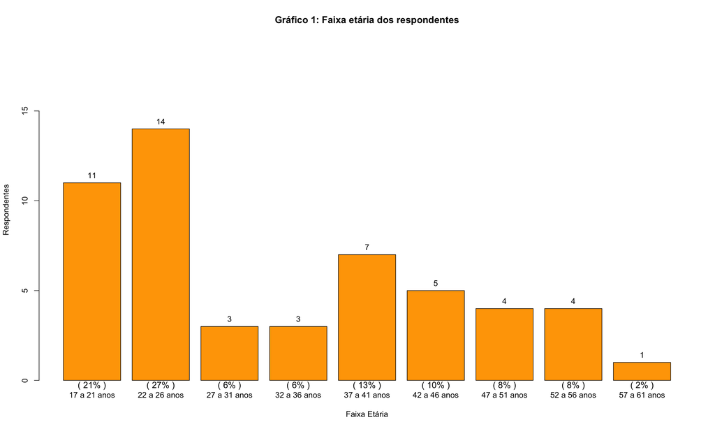

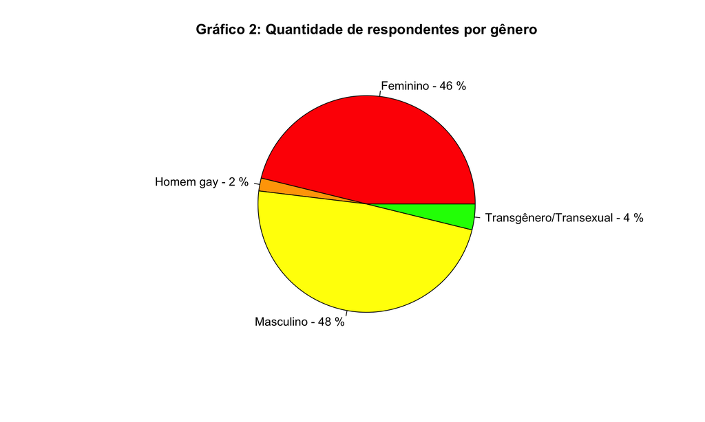

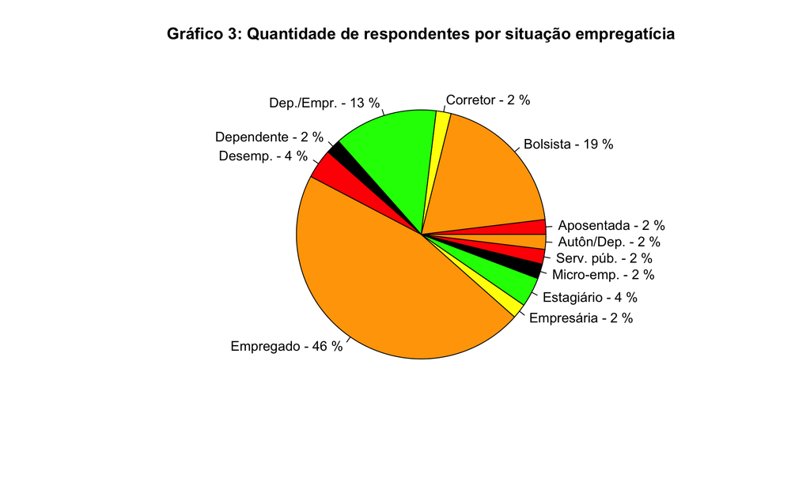

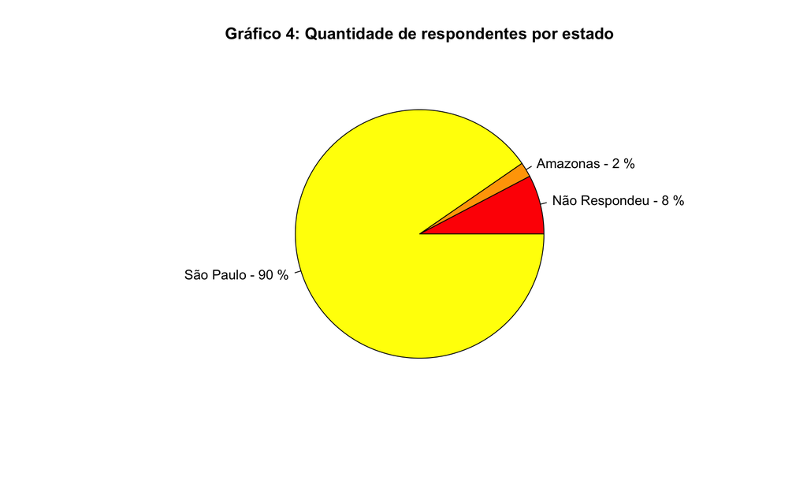

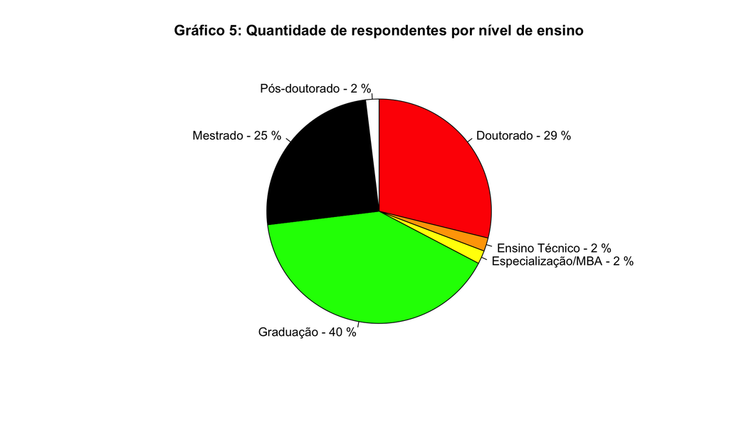